# Take Home Exercise 02

A peer review for mutual learning and growth.

Rakendu Ramesh https://www.linkedin.com/in/rakendu-ramesh/ (Singapore Management University)https://www.linkedin.com/showcase/smumitb/  
2022-05-01

# Overview

In this Take Home exercise, I would like to review my esteemed peer Jiarui Cui’s [*Take Home Ex 01*](https://jiarui-cui-isss608.netlify.app/th_ex/th_ex01). With this review, I hope to learn from my peer and hope to shed some light on the highlights of her first assignment.

## Getting Started

We will first load the required packages using the below code chunk

```r
packages = c('tidyverse','ggdist','gghalves','ggthemes','hrbrthemes','ggridges','patchwork')
for(p in packages){
  if(!require(p, character.only = T)){
    install.packages(p)
  }
  library(p, character.only = T)
}
```

## Importing Data

The code chunk below imports *Participants.csv* from the data folder by using [`read_csv()`](https://readr.tidyverse.org/reference/read_delim.html) function of [**readr**](https://readr.tidyverse.org/index.html) package into R and save it as a tibble dataframe called *participants_data*.

```r
participants_data <- read_csv("data/Participants.csv")
jobs <- read_csv('data/Jobs.csv')
```

I believe the overlapping plots makes comparison easier. We can see that the joviality is generally low among all education levels. Also it can be seen taht more people with Low Education Level have low joviality where as the graduate group has a more equitable density at low and high joviality values.

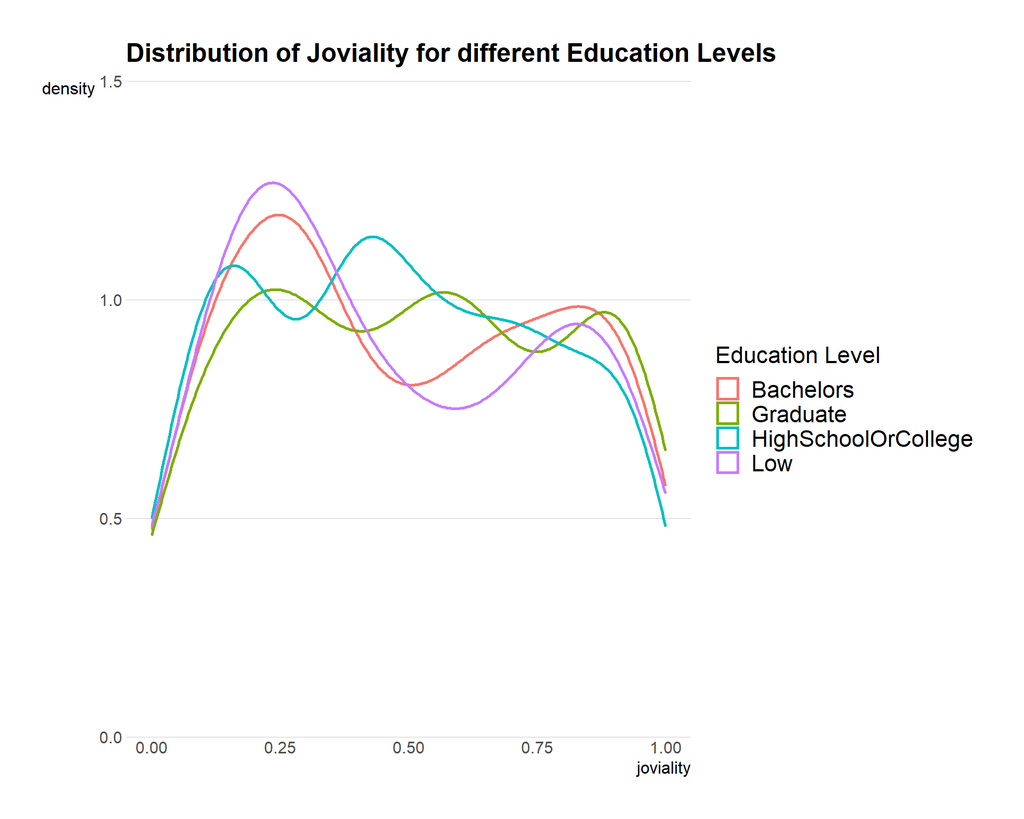

```r
ggplot(participants_data,
       aes(x=joviality, colour = educationLevel))+
  geom_density(size =1)+
  labs(colour = "Education Level")+
  ggtitle("Distribution of Joviality for different Education Levels")+
  theme_ipsum(axis_title_size = 12, grid="Y")+
  theme(axis.title.y = element_text(angle=0),
        axis.title = element_text(size=16),
        axis.text = element_text(size =16),
        legend.title = element_text(size =16),
        legend.text = element_text(size = 16)
        )+
  scale_y_continuous(expand = c(0,0),limits = c(0,1.5))
```

## Disturbing trend of fewer people with higher education level having kids.

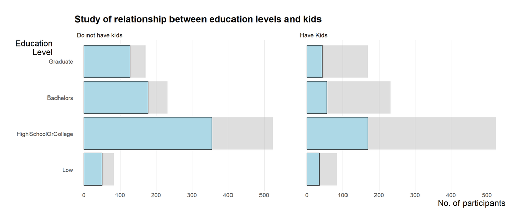

```r
level_order <- c('Low','HighSchoolOrCollege','Bachelors','Graduate')
d <- participants_data
d_bg <- d[,-3]
ggplot(d, aes(x = factor(educationLevel,levels = level_order))) +
  geom_bar(data=d_bg, fill="grey", alpha=.5) +
  geom_bar(colour="black", fill = "light blue") +
  coord_flip()+
  guides(fill = FALSE) +
   theme_ipsum(axis_title_size = 16, grid ="X")+
  theme(axis.title.y=element_text(angle= 0, margin = margin(r=-70)),
        axis.title = element_text(size=16),
        axis.text = element_text(size =16))+
  xlab("Education\nLevel")+
  ylab("No. of participants")+
    facet_wrap(~ haveKids,
             labeller = labeller(haveKids = c("TRUE" = "Have Kids",
                                              "FALSE" = "Do not have kids")))+
  ggtitle("Study of relationship between education levels and kids")
```

## Joviality index by age group

The density plot for joviality index for different age groups clearly show that more people in the age group 18-30 have higher joviality index where as more people in th eage group 40 -60 have lower joviality. Having kids seem to have made a difference in the joviality of age group 18-40. The plot is clear. I would only recommend minor aesthetic changes for easy readability, like making the y axis title horizontal, removing the minor grid lines, increasing thickness of the density lines and adding yrs to the facet wrap labels.

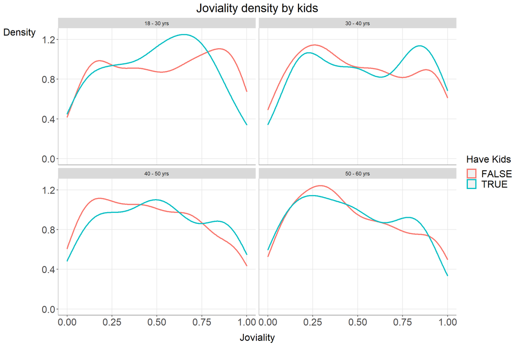

```r
participants_data$agegroup <- cut(participants_data$age, breaks = c(17,30,40,50,60),
                             labels = c("18 - 30 yrs","30 - 40 yrs","40 - 50 yrs","50 - 60 yrs"))


ggplot(data=participants_data,
       aes(x =joviality,colour = haveKids)) +
  geom_density(size = 1)+
  ylab("Density")+
  xlab("Joviality")+
  labs(colour = "Have Kids")+
  theme(axis.title.y=element_text(angle =0, margin = margin(t=-50,r=10)),
        axis.title.x=element_text(margin = margin(t=10)),
        panel.grid.minor.y = element_blank(),
        panel.grid.minor.x = element_blank(),
        panel.grid.major.x = element_line(colour = "grey90"),
        panel.grid.major.y = element_line(colour = "grey90"),
        panel.background = element_rect(fill = "white"),
        axis.title = element_text(size=16),
        axis.text = element_text(size =16),
        plot.title = element_text(size =20,hjust = 0.5),
        legend.title = element_text(size =16),
        legend.text = element_text(size = 16))+
  facet_wrap(~ agegroup,nrow = 2)+
  annotate("segment", x=-Inf, xend=Inf, y=-Inf, yend=-Inf, colour = "grey50")+
  annotate("segment", x=-Inf, xend=-Inf, y=-Inf, yend=Inf, colour = "grey50")+
  ggtitle("Joviality density by kids")
```

## Joviality Index by Education Level

The same aesthetic changes can be applied to Jovilaity index of participants having kids and not by their education level.

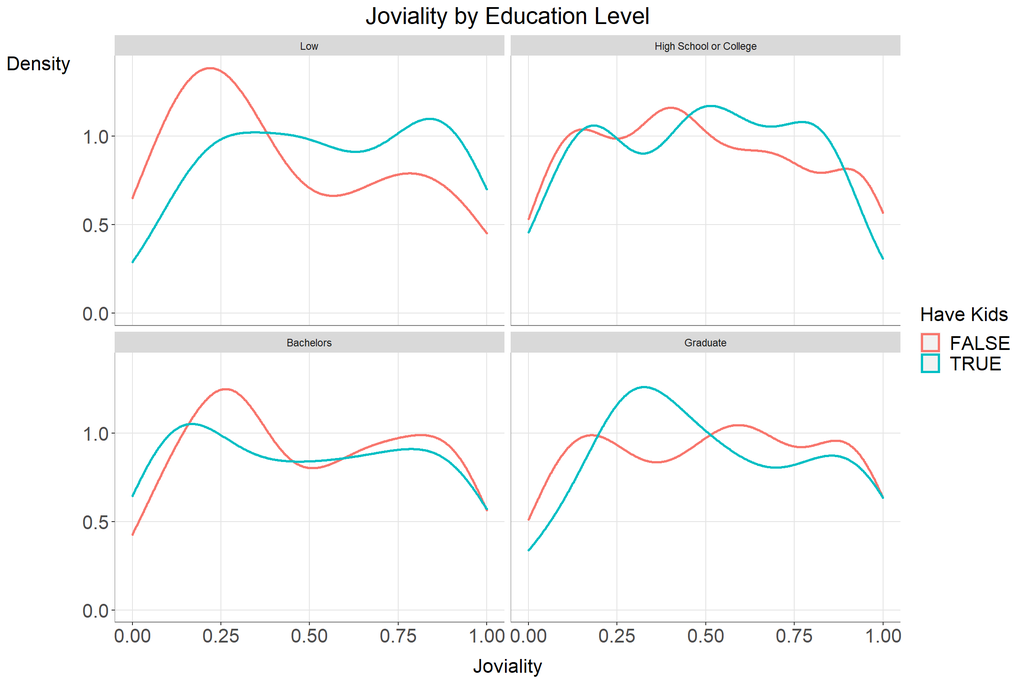

```r
level_order <- c('Low','HighSchoolOrCollege','Bachelors','Graduate')

participants_data$educationLevel <- factor(participants_data$educationLevel, levels = level_order)

ggplot(data=participants_data,
       aes(x =joviality,colour = haveKids)) +
  geom_density(size = 1)+
  facet_wrap(~ educationLevel,nrow = 2,labeller = labeller(educationLevel = c("Low" = "Low",
                                                                              "HighSchoolOrCollege" = "High School or College",
                                                                              "Bachelors" = "Bachelors",
                                                                              "Graduate" = "Graduate")))+
  ylab("Density")+
  xlab("Joviality")+
  labs(colour='Have Kids')+
  theme(axis.title.y=element_text(angle =0, margin = margin(t=-50,r=10)),
        axis.title.x=element_text(margin = margin(t=10)),
        panel.grid.minor.y = element_blank(),
        panel.grid.minor.x = element_blank(),
        panel.grid.major.x = element_line(colour = "grey90"),
        panel.grid.major.y = element_line(colour = "grey90"),
        panel.background = element_rect(fill = "white"),
        axis.title = element_text(size=16),
        axis.text = element_text(size =16),
        plot.title = element_text(size =20,hjust = 0.5),
        legend.title = element_text(size =16),
        legend.text = element_text(size = 16)
        )+
  annotate("segment", x=-Inf, xend=Inf, y=-Inf, yend=-Inf, colour = "grey50")+
  annotate("segment", x=-Inf, xend=-Inf, y=-Inf, yend=Inf, colour = "grey50")+
  ggtitle("Joviality by Education Level")
```

## Hourly Rate by Education Requirement

This graph is a good addition to the demographic study of the city. Though it is not specific about the people, it does say about their living standards. We know from the above graphs that the majority of the city are High School or college educated. From the box plot below, we can see that their salary rates is the second lowest. I would only make aesthetic changes to this boxplot for better clarity and readability. I will also remove the Legend since it is the same as the axis labels,

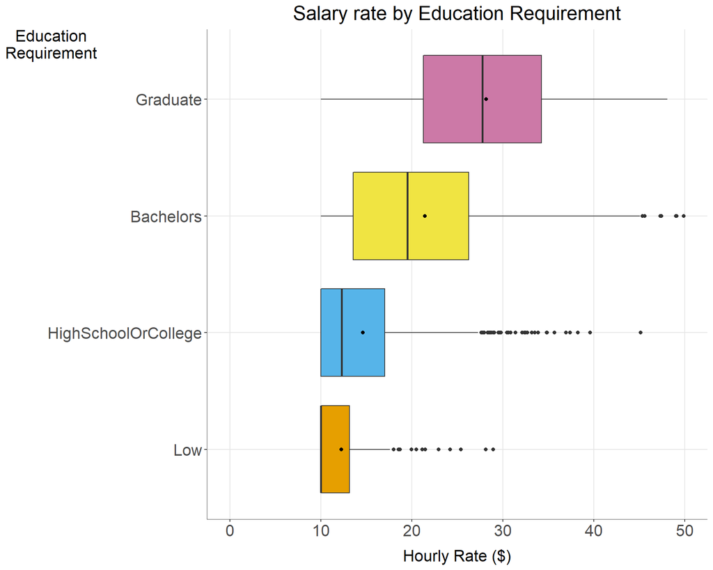

```r
jobs$educationRequirement <- factor(jobs$educationRequirement,
                                      levels = c("Low", "HighSchoolOrCollege",
                                                 "Bachelors", "Graduate"))
cbp1 <- c("#E69F00", "#56B4E9","#F0E442", "#CC79A7")

ggplot(data=jobs, aes(y = hourlyRate,
                      x = educationRequirement,
                      fill = educationRequirement)) +
  labs(fill = "Education Requirement") +
  geom_boxplot() +
  scale_fill_manual(values = cbp1) +
  ylim(0, 50) +
  stat_summary(geom = "point",fun="mean") +
  ylab("Hourly Rate ($)")+
  xlab("Education\nRequirement")+
  coord_flip()+
  theme(axis.title.y=element_text(angle =0, margin = margin(t=-50,r=-50)),
        axis.title.x=element_text(margin = margin(t=10)),
        panel.grid.minor.y = element_blank(),
        panel.grid.minor.x = element_blank(),
        panel.grid.major.x = element_line(colour = "grey90"),
        panel.grid.major.y = element_line(colour = "grey90"),
        panel.background = element_rect(fill = "white"),
        axis.text = element_text(size =16),
        axis.line = element_line(color="grey25", size = 0.02),
        axis.title = element_text(size=16),
        legend.position = "none",
        plot.title = element_text(size =20,hjust = 0.5))+
  ggtitle("Salary rate by Education Requirement")
```

## Conclusion

Finally, a conclusion will be nice, pointing out the highlights which help us to understand the demographic of the city and also combine the corresponding visualizations using patchwork.